# QK 2nd Ed Ch 5

The *R* code here is useful for exploratory data analyses. It does not accompany any specific box, but is linked to Figures.

### Preliminaries

We start by loading a set of packages used commonly and some graphics tweaks.

Figures 5.1 and 5.2 are Illustrator files, tweaked from the first edition.

## Figure 5.3

This figure uses the Low anesthetic example already used in Chapters 2-4 First do dotplot, then do boxplot Inset boxplot into top 10% of dotplot space First for alpha

| anesth | co2 |
| --- | --- |
| iso | 43 |
| iso | 35 |
| iso | 50 |
| iso | 39 |
| iso | 56 |
| iso | 54 |

```r
#Create two subsets of the data, to be used for left and right panels. Could do this with facets, but it's harder to assemble box and dot plots in this case.
# Make sure scales are constant for all graphs, particularly for the two anesthetic types
lowac<-subset(lowco2,anesth=="ac")
lowis<-subset(lowco2,anesth=="iso")

p1<-ggplot(lowac , aes(x=co2)) +
    geom_dotplot()+
  labs(x="CO2", y=NULL)+
  xlim(20,120)+
    theme(
      axis.title.y = element_blank(),
      axis.text.y = element_blank(),
      axis.ticks.y=element_blank(),
      axis.line.y= element_blank()
      )+
    theme_qk()

p2<-ggplot(lowac, aes(x=co2)) +
  geom_boxplot()+
  xlim(20,120)+
  theme_void()
p3<-ggplot(lowis , aes(x=co2)) +
    geom_dotplot()+
  labs(x="CO2", y=NULL)+
  xlim(20,120)+
    theme(
      axis.title.y = element_blank(),
      axis.text.y = element_blank(),
      axis.ticks.y=element_blank(),
      axis.line.y= element_blank()
      )+
    theme_qk()

p4<-ggplot(lowis, aes(x=co2)) +
  geom_boxplot()+
  xlim(20,120)+
  theme_void()
f5_3<-p2+p4+p1+p3 +plot_layout(ncol=2, height=c(.1,.9)) #Assembles four panels and sets box plots to use top 10% with larger space for dot plots
```

|  | t | l | b | r |
| --- | --- | --- | --- | --- |
| 1: | 1 | 1 | 1 | 1 |
| 2: | 2 | 1 | 2 | 1 |
| 3: | 1 | 2 | 1 | 2 |
| 4: | 2 | 2 | 2 | 2 |

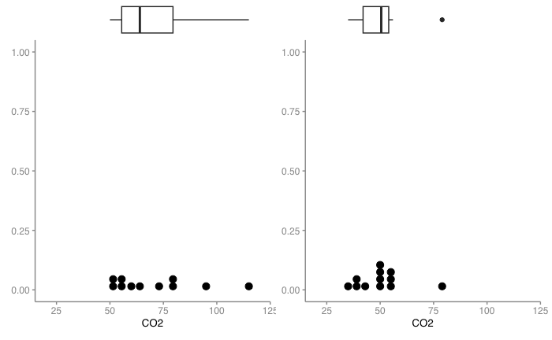

```r
f5_3
```

Figure 5.4 is an Illustrator file

### Figure 5.5

This figure continues with the Low dataset

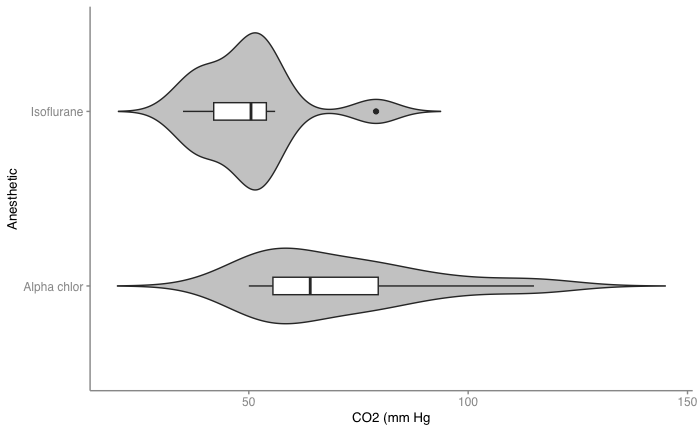

```r
f5_5<-ggplot(data=lowco2, aes(x=anesth, y=co2))+
  geom_violin(trim=FALSE, fill=lf)+
  xlab("Anesthetic")+ ylab("CO2 (mm Hg")+
  scale_x_discrete(labels=c("ac" = "Alpha chlor", "iso" = "Isoflurane"))+
  geom_boxplot(width=0.1)+   # embeds boxplot into violins
  coord_flip()+
  theme_qk()
f5_5
```

### Figure 5.6

The data file for the q-q plots is the Loyn forest bird example used in several chapters

|  | t | l | b | r |
| --- | --- | --- | --- | --- |
| 1: | 1 | 1 | 1 | 1 |
| 2: | 1 | 2 | 1 | 2 |

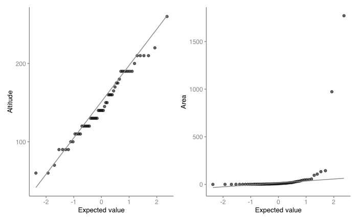

### Figure 5.7

For this figure uses data from Booth et al. (2011) linking the size of green turtle (*Chelonia mydas*) hatchlings to their incubation temperature. It uses the package *ggMarginal* to add boxplots to the scatterplot borders

```r
booth <- read.csv("data/booth.csv", stringsAsFactors=TRUE)
head(booth)
```

|  | eggmass | hatchmass | hatchsize | nesttemp |
| --- | --- | --- | --- | --- |
| 1 | 54.6 | 25.8 | 1913 | 29.3 |
| 2 | 54.5 | 25.0 | 1838 | 29.5 |
| 3 | 49.3 | 23.7 | 1757 | 30.3 |
| 4 | 55.9 | 27.3 | 1890 | 29.6 |
| 5 | 55.7 | 27.6 | 2040 | 28.2 |
| 6 | 53.9 | 27.2 | 1818 | 29.6 |

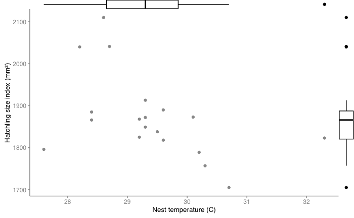

```r
p<-ggplot(booth, aes(x=nesttemp, y=hatchsize))+
  geom_point(color=sc)+
  xlab("Nest temperature (C)")+ylab("Hatchling size index (mm²)")+
  theme_qk()
f5_7<-ggMarginal(p,size=20, type="boxplot")
f5_7
```

### Figure 5.8

This figure uses data on invertebrate diversity in clumps of mussels from Peake & Quinn, used in a couple of chapters. It illustrates different smoothing options, including loess with varied smoothing parameters and a GAM smoother.

```r
peakquinn <- read.csv("data/peakquinn.csv")
head(peakquinn)
```

|  | area | indiv | species |
| --- | --- | --- | --- |
| 1 | 516.00 | 18 | 3 |
| 2 | 469.06 | 60 | 7 |
| 3 | 462.25 | 57 | 6 |
| 4 | 938.60 | 100 | 8 |
| 5 | 1357.15 | 48 | 10 |
| 6 | 1773.66 | 118 | 9 |

```r
#3 panels
# loess with 0.25 smoothing parameter
pc<-ggplot(data = peakquinn, aes(x=area,y=species))+
  geom_point(color=sc)+
  geom_smooth(se=FALSE, span=0.25, color=lc)+
  theme(
    plot.title = element_text(hjust = 0.5)
      ) +
  xlab("Area")+ylab("No. of species")+ggtitle("Loess 0.25")
# Smoothing parameter to 0.75 for smoother fit
pd<-ggplot(data = peakquinn, aes(x=area,y=species))+
  geom_point(color=sc)+
  geom_smooth(se=FALSE, span=0.75, color=lc)+
  theme(
    plot.title = element_text(hjust = 0.5)
  )+
  xlab("Area")+ylab(" ")+ggtitle("Loess 0.75")

# Now use gam smoothing to match ggplot approach, with gam fitted to large (n>1000) data sets
pe<-ggplot(data = peakquinn, aes(x=area,y=species))+
  geom_point(color=sc)+
  geom_smooth(se=FALSE, method="gam", color=lc)+
  theme(
    plot.title = element_text(hjust = 0.5)
  )+
  xlab("Area")+ylab(" ")+ggtitle("GAM")
f5_8<-pc+pd+pe&theme_qk()
```

|  | t | l | b | r |
| --- | --- | --- | --- | --- |
| 1: | 1 | 1 | 1 | 1 |
| 2: | 1 | 2 | 1 | 2 |
| 3: | 1 | 3 | 1 | 3 |

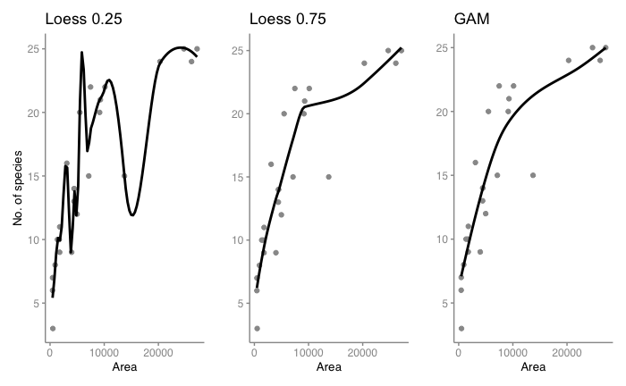

```r
f5_8
```

Figure 5.9 is an Illustrator file

### Figure 5.10

This figure illustrates residual plots. The first line of code runs a linear model using species number, with clump area as the predictor. The data continues with the Peake-Quinn example

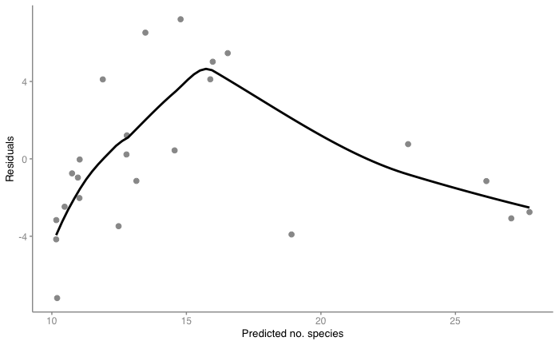

```r
pq.lm<-lm(peakquinn$species~peakquinn$area)
f5_10<-ggplot(pq.lm, aes(x = pq.lm$fitted.values, y = pq.lm$residuals)) +
  geom_point(color=sc, size = ss, alpha= 1)+
  geom_smooth(method="loess", color=lc,se=FALSE)+
  labs(x = "Predicted no. species", y = "Residuals")+
  theme_qk()
f5_10
```

### Send figures to pdf

Note: chunk set to not run, as only used for book. Change output file names if you need to save files. height and width are parameters passed from appearance.R

```r
ggsave("../Illustrator/QK F5_03.pdf", plot = f5_3, height = ph,width = pww, units='cm')
ggsave("../Illustrator/QK F5_05.pdf", plot = f5_5, height = ph,width = pw, units='cm')
ggsave ("../Illustrator/QK F5_06.pdf", plot = f5_6, height = ph, width = pwm, units='cm')
ggsave("../Illustrator/QK F5_07.pdf",plot = f5_7, height = ph,width = pw, units='cm')
ggsave ("../Illustrator/QK F5_08.pdf", plot = f5_8, height = ph, width = pww, units='cm')
ggsave("../Illustrator/QK F5_10.pdf", plot = f5_10, height = ph,width = pw, units='cm')
```